# Home Price Prediction with Population Trends

**Summary** : This project analyzes CPI-adjusted house prices in the United States from 1975 to 2025.The analysis compares regional growth and volatility in prices.The study also examines the link between population density and price change. KNN classification predicts the region of a state with high accuracy. Naïve Bayes performs poorly compared to KNN.

# Load and prepare the data

```r
# Install (only if needed)
if (!require("tidyverse")) install.packages("tidyverse")
if (!require("readr")) install.packages("readr")
if (!require("readxl")) install.packages("readxl")
if (!require("lubridate")) install.packages("lubridate")
if (!require("ggrepel")) install.packages("ggrepel")

library(tidyverse); library(readr); library(readxl); library(lubridate); library(ggrepel)

# 1) Freddie Mac HPI (FMHPI)
avg_house_price <- read_csv("fmhpi_master_file.csv")

# Extract state code from GEO_Name and build a proper Date column,
# and drop rows where State could not be identified.
avg_house_price <- avg_house_price %>%
  mutate(
    # Pull the LAST two uppercase letters from GEO_Name
    State = str_extract(GEO_Name, "[A-Z]{2}$"),

    # Construct a Date from Year and Month (day set to 1).
    Date  = make_date(Year, Month, 1),

    # Make sure the index columns are numeric
    Index_NSA = as.numeric(Index_NSA),
    Index_SA  = as.numeric(Index_SA)
  ) %>%

  # Remove any rows where State was not matched
  filter(!is.na(State))

# Aggregate to State–Date
avg_house_price <- avg_house_price %>%
  group_by(State, Date, Year, Month) %>%
  summarise(
    Index_NSA = mean(Index_NSA, na.rm = TRUE), # Average the non-seasonally-adjusted HPI
    AvgPrice  = mean(Index_SA,  na.rm = TRUE), # Average the seasonally-adjusted HPI

    .groups = "drop" # Ungroup the result
  )
```

```r
# 2) CPI: tidy to Year/Month and keep only Date + cpi
cpi_raw <- read_excel("cpi.xlsx", skip = 4)

# Rename first 14 cols if present
colnames(cpi_raw)[1:14] <- c("Drop","Year","Jan","Feb","Mar","Apr","May","Jun",
                             "Jul","Aug","Sep","Oct","Nov","Dec")

# Remove the "Drop" column, keep only rows with a valid Year
cpi_clean <- cpi_raw[, -1] %>%
  filter(!is.na(Year)) %>%
  mutate(Year = as.integer(Year)) %>%
  mutate(across(Jan:Dec, ~ as.numeric(.)))

# Convert from wide (one row per Year with 12 month columns) to long (one row per Year-Month):
#  - pivot the month columns into two columns: MonthName and Value (the CPI)
#  - translate MonthName to numeric Month using base R's month abbreviations
#  - build a proper Date (first of each month) for clean time‑series joins later
#  - keep only the study window (1975–2025)
#  - and keep just the two columns we’ll need downstream: Date and cpi
cpi_long <- cpi_clean %>%
  pivot_longer(cols = Jan:Dec, names_to = "MonthName", values_to = "Value") %>%
  mutate(
    Month = match(MonthName, month.abb),
    Date  = make_date(Year, Month, 1)
  ) %>%
  filter(Year >= 1975, Year <= 2025) %>%
  dplyr::select(Date, cpi = Value)

#Check the results
head(cpi_long)
```

| Date | cpi |
| --- | --- |
| 1975-01-01 | 52.1 |
| 1975-02-01 | 52.5 |
| 1975-03-01 | 52.7 |
| 1975-04-01 | 52.9 |
| 1975-05-01 | 53.2 |
| 1975-06-01 | 53.6 |

```r
# 3) Join CPI to prices and compute CPI-adjusted price

# Join the monthly house price index table (avg_house_price) to the monthly CPI table (cpi_long)on the common Date column.
# inner_join() keeps only the rows where Date appears in BOTH datasets Ensures we only keep months that have both house price data and CPI data.
avg_house_price_cpi <- inner_join(avg_house_price, cpi_long, by = "Date") %>%

  # Compute an inflation-adjusted price index
  mutate(AvgPrice_Adj = (AvgPrice / cpi) * 100)

# 4) Region map (CSV with columns: State (full), Code (abbr), Region)

# we already have state_abbrevs.txt
st_abbrs <- read.table("state_abbrevs.txt", header = TRUE)

# Attach StateName and Region using the state code
avg_house_price_cpi <- avg_house_price_cpi %>%
  left_join(st_abbrs, by = c("State" = "Code")) %>%

  # Left join keeps ALL rows from avg_house_price_cpi
  # and adds matching columns from st_abbrs where State == Code
  rename(StateName = State.y)
```

# 1) House prices over time

# Plot of change in average housing price in US per year (CPI adjusted)

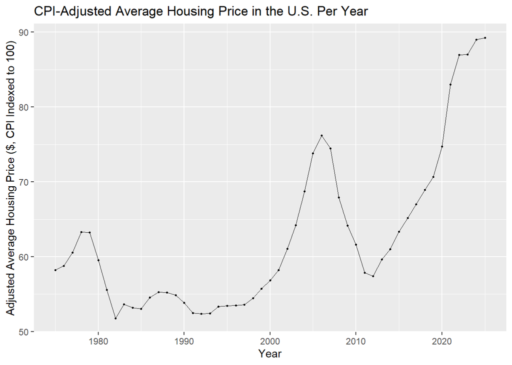

```r
# Collapse monthly data to yearly by taking the mean across months AND states.
# That effectively gives each state equal weight
avg_price_us_adj <- avg_house_price_cpi %>%
  mutate(Year = year(Date)) %>% # extract calendar year
  group_by(Year) %>%
  summarise(AvgPrice_Adj = mean(AvgPrice_Adj, na.rm = TRUE),  .groups = "drop")  # average over all states & months

ggplot(avg_price_us_adj, aes(x = Year, y = AvgPrice_Adj)) +
  geom_line() + geom_point() +
  ggtitle("CPI-Adjusted Average Housing Price in the U.S. Per Year") +
  ylab("Adjusted Average Housing Price ($, CPI Indexed to 100)") +
  theme_grey(base_size = 22)
```

### Figure 1: CPI-Adjusted Average Housing Price in the U.S. Per Year

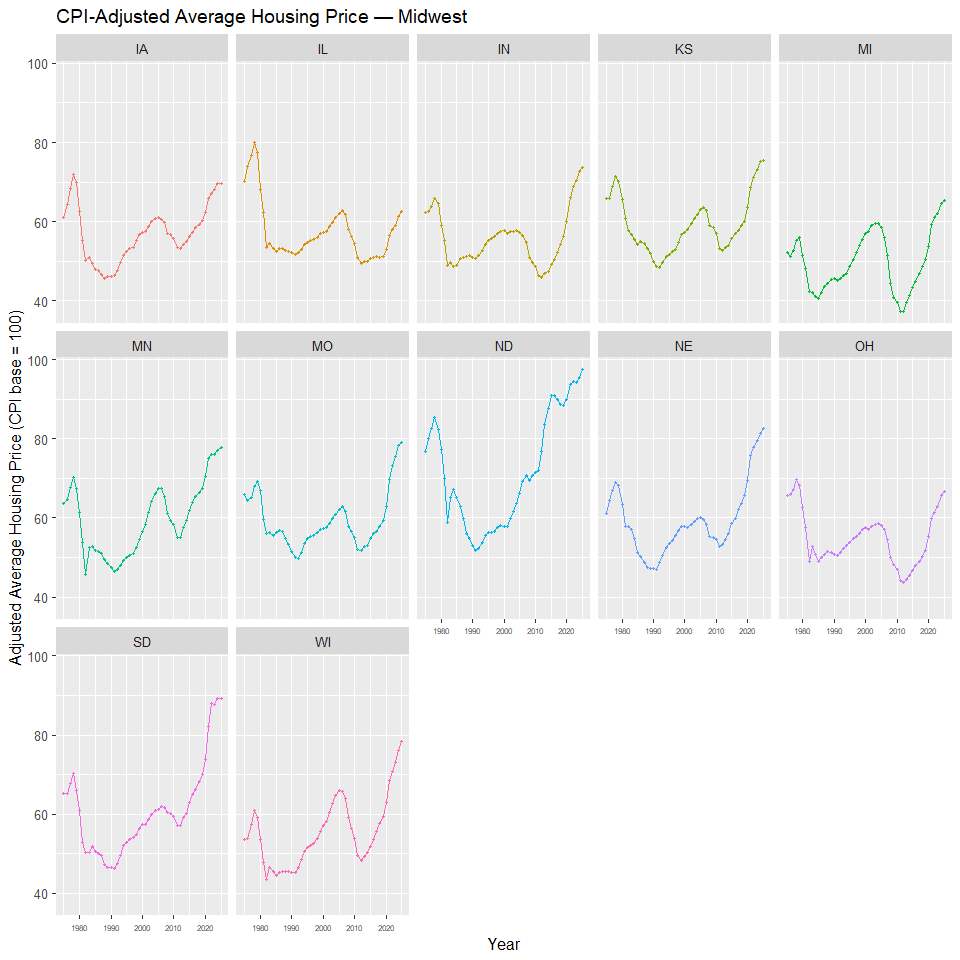

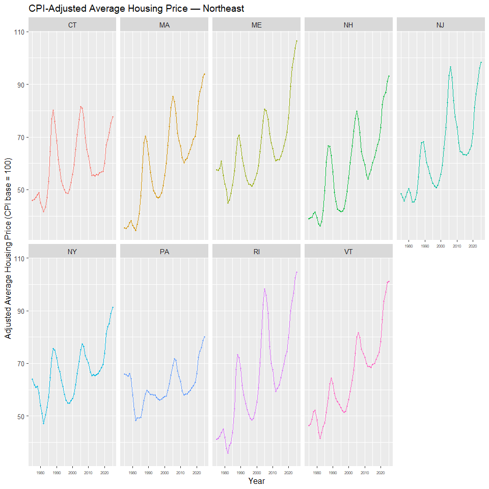

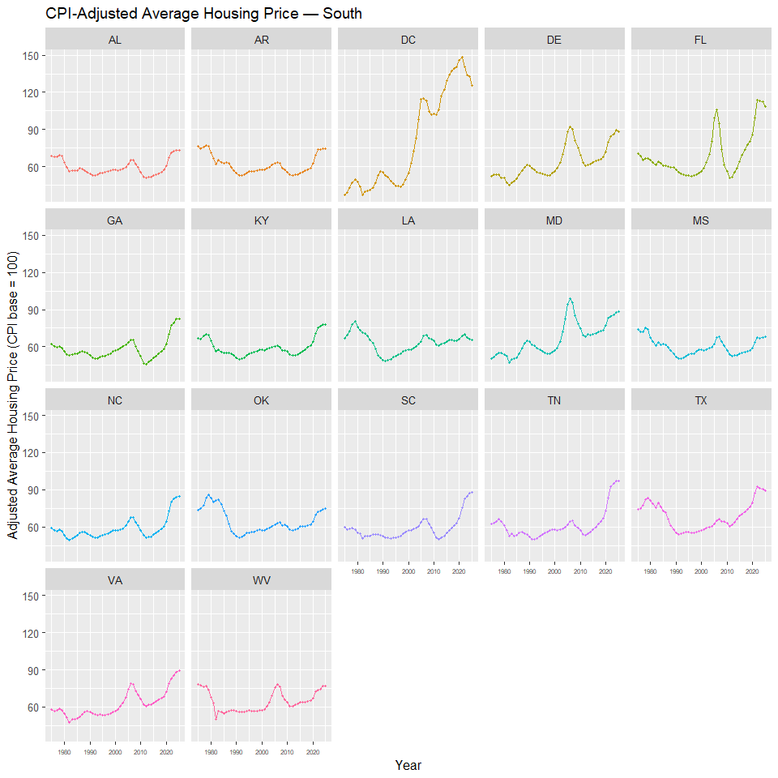

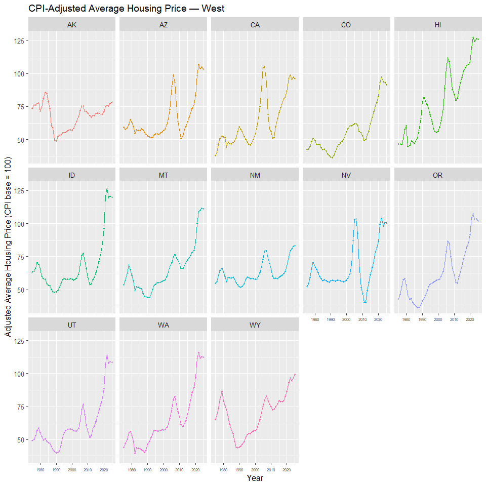

```r
# 2. By state (paged per region to avoid tiny facets)
# Collapse to yearly per state so each facet shows one state’s yearly path
avg_state_adj <- avg_house_price_cpi %>%
  mutate(Year = year(Date)) %>%
  group_by(Year, State, Region) %>%
  summarise(AvgPrice_Adj = mean(AvgPrice_Adj, na.rm = TRUE), .groups = "drop") # annual average per state

# Collect unique region names
regions <- sort(unique(avg_state_adj$Region))

# Iterate over regions so each print() produces a separate plot page
for (r in regions) {
  df <- dplyr::filter(avg_state_adj, Region == r)

  # Facet by state so each small multiple is readable
  print(
    ggplot(df, aes(Year, AvgPrice_Adj, color = State, group = State)) +
      geom_line() + geom_point(size = 0.6) +
      facet_wrap(~ State, ncol = 5) +
      ggtitle(paste("CPI-Adjusted Average Housing Price —", r)) +
      xlab("Year") + ylab("Adjusted Average Housing Price (CPI base = 100)") +
      theme_grey(base_size = 12) +
      theme(legend.position = "none",
            axis.text.x = element_text(size = 6))
  )
}
```

### Figure 2: CPI-Adjusted Average Housing Price by State and Region

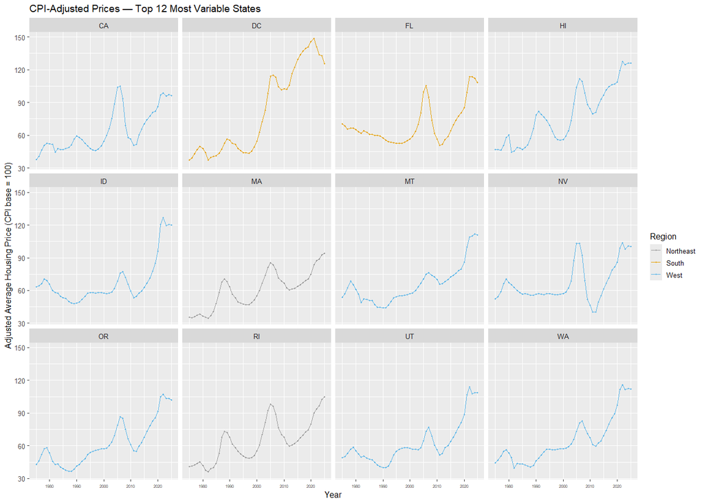

```r
# Top 12 most variable states (CPI-adjusted)
topN <- avg_state_adj %>%
  group_by(State) %>%
  summarise(vol = sd(AvgPrice_Adj, na.rm = TRUE), .groups = "drop") %>%
  slice_max(vol, n = 12)

df_top <- dplyr::semi_join(avg_state_adj, topN, by = "State")

ggplot(df_top, aes(Year, AvgPrice_Adj, color = Region)) +
  geom_line() + geom_point(size = 0.8) +
  facet_wrap(~ State, ncol = 4) +
  ggtitle("CPI-Adjusted Prices — Top 12 Most Variable States") +
  xlab("Year") + ylab("Adjusted Average Housing Price (CPI base = 100)") +
  scale_color_manual(values = cb_palette) +
  theme_grey(base_size = 12) +
  theme(axis.text.x = element_text(size = 6))
```

### Figure 3: CPI-Adjusted Prices — Top 12 Most Variable States

# Faceting by region : CPI-adjusted average housing prices per year

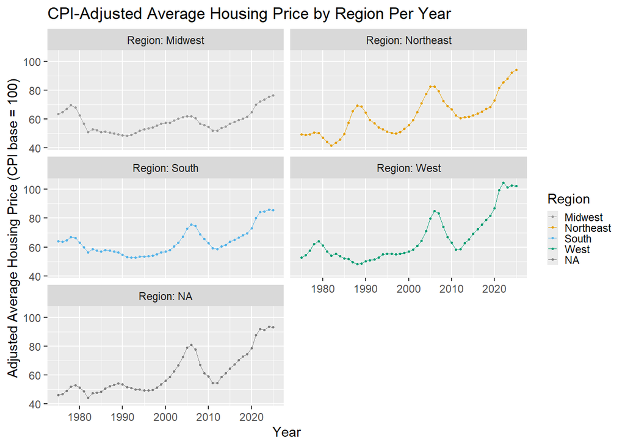

```r
avg_region_adj <- avg_house_price_cpi %>%
  # Extract calendar year from monthly date
  mutate(Year = year(Date)) %>%
  group_by(Year, Region) %>% # Group by year and region
  summarise(AvgPrice_Adj = mean(AvgPrice_Adj, na.rm = TRUE), .groups = "drop")  # Mean CPI-adjusted price across states in that region

ggplot(avg_region_adj, aes(x = Year, y = AvgPrice_Adj, color = Region)) +
  geom_line() + geom_point() +
  facet_wrap(~ Region, ncol = 2, labeller = "label_both") +
  xlab("Year") + ylab("Adjusted Average Housing Price (CPI base = 100)") +
  ggtitle("CPI-Adjusted Average Housing Price by Region Per Year") +
  scale_color_manual(values = cb_palette) +
  theme_grey(base_size = 22)
```

### Figure 4: CPI-Adjusted Average Housing Price by Region Per Year

# 2) Population density and changes in house prices

# Using state area from state.x77; add DC manually.

```r
# State areas
state.area <- data.frame(State = state.name, Area = as.numeric(state.x77[, "Area"])) %>%
  bind_rows(tibble(State = "District of Columbia", Area = 61.05))
```

# Prepare the data

```r
# Historical population by (State, Year, Population): provide/ensure 3 columns in CSV
population <- readr::read_csv(
  "historical_state_population_by_year.csv",
  col_names = c("State", "Year", "Population"),
  col_types  = "cin"   # c=character, i=integer, n=numeric
)

# Aggregate in case of duplicates
population <- population %>%
  group_by(State, Year) %>%
  summarise(Population = sum(Population, na.rm = TRUE), .groups = "drop")

# Map to full state names using codes, then attach Area
# st_abbrs has Code (abbr), State.y (full), Region
population <- population %>%
  left_join(st_abbrs, by = c("State" = "Code")) %>%
  rename(StateName = State.y)

census <- population %>%
  left_join(state.area, by = c("StateName" = "State")) %>%
  mutate(
    Population = as.numeric(Population),
    Area       = as.numeric(Area)
  )
```

# U.S. density vs U.S. % price change (1975 baseline)

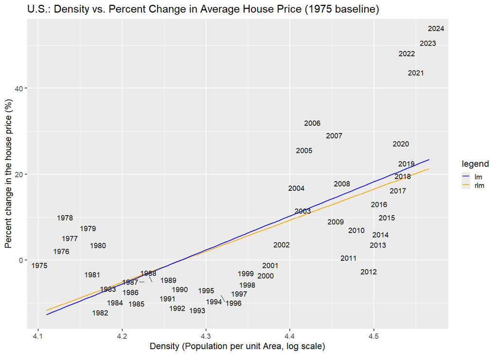

```r
# U.S. density per year (exclude 2025)
census_us_year <- census %>%
  filter(Year != 2025) %>%
  group_by(Year) %>%
  summarise(
    Population = sum(Population, na.rm = TRUE),
    Area       = sum(Area, na.rm = TRUE),
    density    = Population / Area,
    .groups = "drop"
  )

# U.S. avg price per year (CPI-adjusted if available)
price_us_year <- avg_house_price_cpi %>%
  mutate(Year = year(Date)) %>%
  group_by(Year) %>%
  summarise(AvgPrice = mean(AvgPrice_Adj, na.rm = TRUE), .groups = "drop") %>%
  filter(Year != 2025)

# % change vs 1975
base_1975 <- price_us_year %>% filter(Year == 1975) %>% pull(AvgPrice)
us_change <- price_us_year %>%
  mutate(change = ((AvgPrice - base_1975) / base_1975) * 100) %>%
  inner_join(census_us_year, by = "Year")

ggplot(us_change, aes(x = log(density), y = change)) +
  geom_smooth(method = "rlm", se = FALSE, aes(colour = "rlm")) +
  geom_smooth(method = "lm",  se = FALSE, aes(colour = "lm")) +
  ggrepel::geom_text_repel(aes(label = Year), size = 5, max.overlaps = Inf) +
  xlab("Density (Population per unit Area, log scale)") +
  ylab("Percent change in the house price (%)") +
  ggtitle("U.S.: Density vs. Percent Change in Average House Price (1975 baseline)") +
  scale_colour_manual(name = "legend", values = c("blue", "orange")) +
  theme_grey(base_size = 18)
```

### Figure 5: U.S. Density vs. Percent Change in Average House Price (1975 Baseline)

The plot shows the relationship between population density and percentage change in U.S. average housing prices since 1975. Higher density years are linked with larger price increases. Both linear and robust regression lines show a positive trend.

# By State: latest year (≠ 2025) density vs % change from 1975

```r
latest_year <- max(avg_house_price$Year[avg_house_price$Year != 2025])

# Density in latest year per state
census_state_latest <- census %>%
  filter(Year == latest_year) %>%
  mutate(density = Population / Area) %>%
  dplyr::select(State = State, StateName, density)

# Average price in 1975 per state
price_1975 <- avg_house_price_cpi %>%
  mutate(Year = year(Date)) %>%
  filter(Year == 1975) %>%
  group_by(State) %>%
  summarise(AvgPrice1975 = mean(AvgPrice_Adj, na.rm = TRUE), .groups = "drop")

# Average price in latest year per state
price_latest <- avg_house_price_cpi %>%
  mutate(Year = year(Date)) %>%
  filter(Year == latest_year) %>%
  group_by(State) %>%
  summarise(AvgPriceLatest = mean(AvgPrice_Adj, na.rm = TRUE), .groups = "drop")

# Combine and compute % change
price_change_state <- price_1975 %>%
  inner_join(price_latest, by = "State") %>%
  mutate(change = ((AvgPriceLatest - AvgPrice1975) / AvgPrice1975) * 100) %>%
  inner_join(census_state_latest, by = "State")
```

```
**Result**:The correlation between density and cumulative price change is 0.52 .
```

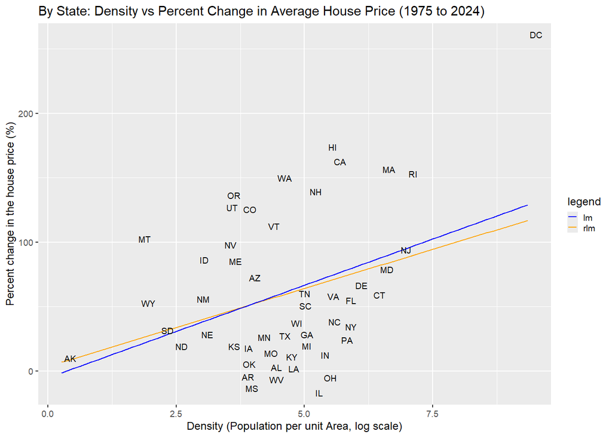

```r
ggplot(price_change_state, aes(x = log(density), y = change)) +
  geom_smooth(method = "rlm", se = FALSE, aes(colour = "rlm")) +
  geom_smooth(method = "lm",  se = FALSE, aes(colour = "lm")) +
  ggrepel::geom_text_repel(aes(label = State), size = 5, max.overlaps = Inf) +
  xlab("Density (Population per unit Area, log scale)") +
  ylab("Percent change in the house price (%)") +
  ggtitle(paste0("By State: Density vs Percent Change in Average House Price (1975 to ", latest_year, ")")) +
  scale_colour_manual(name = "legend", values = c("blue", "orange")) +
  theme_grey(base_size = 18)
```

### Figure 6: By State — Density vs. Percent Change in Average House Price

# Drop Outlier (DC) and show cleaner labels

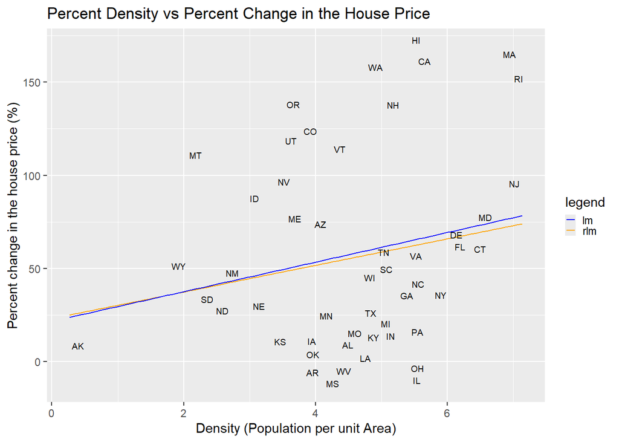

```r
ggplot(filter(price_change_state, State != "DC"),
       aes(x = log(density), y = change)) +
  geom_smooth(method = "rlm", se = FALSE, aes(colour="rlm")) +
  geom_smooth(method = "lm",  se = FALSE, aes(colour="lm")) +
  ggrepel::geom_text_repel(aes(label = State), size = 5, max.overlaps = Inf) +
  xlab("Density (Population per unit Area)") +
  ylab("Percent change in the house price (%)") +
  ggtitle("Percent Density vs Percent Change in the House Price") +
  scale_colour_manual(name="legend", values=c("blue", "orange")) +
  theme_grey(base_size = 22)
```

### Figure 7: Percent Density vs. Percent Change in the House Price

The plot shows the relationship between population density and percentage change in CPI-adjusted housing prices for all states excluding the District of Columbia. High-density states have larger price increases. Both linear and robust regression lines show a positive relationship.

# 3) Changes in population and changes in house prices

```r
# Allowed study years, excluding 2025
yrs_ok <- c(1990, 1999, 2000, 2009, 2010, 2018)

# 1) Standardize census to STATE CODES before we go wide ------------------
# st_abbrs must have columns: State (full name), Code (abbr), Region
# We convert StateName (full) -> Code, and keep Code as the join key.

census_state_year <- census %>%
  mutate(density = Population / Area) %>%
  # map full name -> code
  left_join(st_abbrs, by = c("State" = "Code", "StateName" = "State")) %>%
  dplyr::select(State, Year, Population, density)

# Make a WIDE table by state with Population_YYYY and density_YYYY
census.data.wide <- census_state_year %>%
  filter(Year %in% yrs_ok) %>%
  tidyr::pivot_wider(
    names_from  = Year,
    values_from = c(Population, density),
    names_sep   = "_"
  )

# Population deltas
census.data.change <- tibble(
  State       = census.data.wide$State,
  `1990_2000` = census.data.wide$Population_2000 - census.data.wide$Population_1990,
  `2000_2010` = census.data.wide$Population_2010 - census.data.wide$Population_2000,
  `2010_2018` = census.data.wide$Population_2018 - census.data.wide$Population_2010
) %>%
  pivot_longer(!State, names_to = "Year", values_to = "Population_Change") %>%
  mutate(Year = as.factor(Year))

# 2) Price side (CPI-adjusted), build snapshots via pivot_wider
price_yearly <- avg_house_price_cpi %>%
  mutate(Year = lubridate::year(Date)) %>%
  filter(Year %in% yrs_ok) %>%
  group_by(State, Year) %>%
  summarise(AvgPrice = mean(AvgPrice_Adj, na.rm = TRUE), .groups = "drop")

# One wide row per state with columns P1990, P1999, ...
price_wide <- price_yearly %>%
  mutate(Year = paste0("P", Year)) %>%
  tidyr::pivot_wider(names_from = Year, values_from = AvgPrice)

# Warn which snapshots are missing (causing NAs)
needed_cols <- paste0("P", yrs_ok)
missing_counts <- colSums(is.na(price_wide[, intersect(names(price_wide), needed_cols), drop = FALSE]))
if (any(missing_counts > 0)) {
  message("States with missing price snapshots (counts by column):")
  print(missing_counts[missing_counts > 0])
}

# Compute price deltas (allow NAs if a snapshot is missing)
avg_house_prices.change <- price_wide %>%
  transmute(
    State,
    `1990_2000` = P1999 - P1990,
    `2000_2010` = P2009 - P2000,
    `2010_2018` = P2018 - P2010
  ) %>%
  pivot_longer(!State, names_to = "Year", values_to = "Average_Price_Change") %>%
  mutate(Year = as.factor(Year))

# 3) Merge pop change and price change on STATE CODES
data.change <- left_join(census.data.change, avg_house_prices.change, by = c("State", "Year"))

# attach Region for plotting
data.change <- left_join(data.change, st_abbrs, by = "State")
```

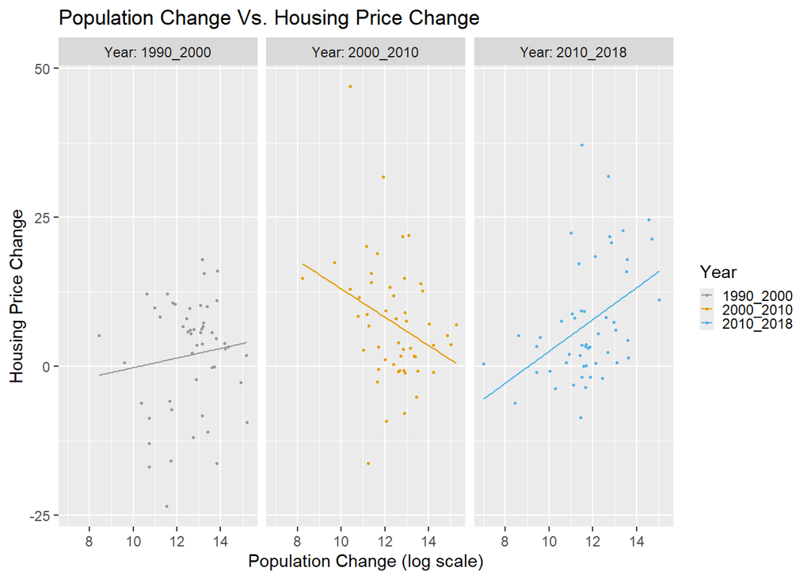

```r
ggplot(data.change,
       aes(x = log(abs(Population_Change)), y = Average_Price_Change,
           group = Year, color = factor(Year))) +
  geom_point() +
  geom_smooth(method = "lm", se = FALSE) +
  ggtitle("Population Change Vs. Housing Price Change") +
  xlab("Population Change (log scale)") +
  ylab("Housing Price Change") +
  scale_color_manual(values = cb_palette) +
  facet_wrap(Year ~ ., labeller = "label_both") +
  labs(color = "Year") +
  theme_grey(base_size = 22)
```

### Figure 8: Population Change vs. Housing Price Change

The plots show the relationship between population change and CPI-adjusted housing price change for each year. Most years show a positive relationship between the two variables. The strength and slope of the relationship vary across years.

## Results

| Region | correlation |
| --- | --- |
| Midwest | -0.6478624 |
| Northeast | 0.3119127 |
| South | 0.9152732 |
| West | 0.7290388 |

```
**Result.** The correlation differs by region
```

# 1. Decide the Prediction Target & Features

# 2. KNN & Naïve Bayes Implementation in R

```r
# Install needed packages
if (!require("caret")) install.packages("caret")
if (!require("class")) install.packages("class")
if (!require("e1071")) install.packages("e1071")

library(caret)
library(class)
library(e1071)

# Prepare data for modeling
# Use the latest year excluding 2025
latest_year <- max(avg_house_price_cpi$Year[avg_house_price_cpi$Year != 2025])
census <- census %>%
  mutate(
    Population = as.numeric(Population),
    Area = as.numeric(Area),
    density = Population / Area
  )
model_df <- avg_house_price_cpi %>%
  filter(Year == latest_year) %>%
  left_join(census %>% filter(Year == latest_year) %>% dplyr::select(StateName, density),
            by = c("StateName")) %>%
  dplyr::select(State, AvgPrice_Adj, density, Region) %>%
  drop_na()

# Convert Region to factor
model_df$Region <- as.factor(model_df$Region)

# Train/test split
set.seed(123)
train_idx <- createDataPartition(model_df$Region, p = 0.8, list = FALSE)
train_data <- model_df[train_idx, ]
test_data  <- model_df[-train_idx, ]

# --- KNN Model ---
# Normalize numeric predictors
norm_vals <- preProcess(train_data[, c("AvgPrice_Adj", "density")], method = c("center", "scale"))
train_norm <- predict(norm_vals, train_data)
test_norm  <- predict(norm_vals, test_data)

knn_pred <- knn(train = train_norm[, c("AvgPrice_Adj", "density")],
                test  = test_norm[, c("AvgPrice_Adj", "density")],
                cl    = train_norm$Region,
                k     = 5)

cat("KNN Accuracy:", mean(knn_pred == test_norm$Region), "\n")
```

```
KNN Accuracy: 0.8583333
```

```r
confusionMatrix(knn_pred, test_norm$Region)
```

```
Confusion Matrix and Statistics

           Reference
Prediction  Midwest Northeast South West
  Midwest        24         0     1    2
  Northeast       0        17     3    2
  South           1         1    35    0
  West            3         3     1   27

Overall Statistics

               Accuracy : 0.8583
                 95% CI : (0.7829, 0.9153)
    No Information Rate : 0.3333
    P-Value [Acc > NIR] : < 2.2e-16

                  Kappa : 0.8084

 Mcnemar's Test P-Value : NA

Statistics by Class:

                     Class: Midwest Class: Northeast Class: South Class: West
Sensitivity                  0.8571           0.8095       0.8750      0.8710
Specificity                  0.9674           0.9495       0.9750      0.9213
Pos Pred Value               0.8889           0.7727       0.9459      0.7941
Neg Pred Value               0.9570           0.9592       0.9398      0.9535
Prevalence                   0.2333           0.1750       0.3333      0.2583
Detection Rate               0.2000           0.1417       0.2917      0.2250
Detection Prevalence         0.2250           0.1833       0.3083      0.2833
Balanced Accuracy            0.9123           0.8795       0.9250      0.8962
```

```r
# --- Naïve Bayes Model ---
nb_model <- naiveBayes(Region ~ AvgPrice_Adj + density, data = train_data)
nb_pred <- predict(nb_model, newdata = test_data)

cat("Naïve Bayes Accuracy:", mean(nb_pred == test_data$Region), "\n")
```

```
Naïve Bayes Accuracy: 0.4833333
```

```r
confusionMatrix(nb_pred, test_data$Region)
```

```
Confusion Matrix and Statistics

           Reference
Prediction  Midwest Northeast South West
  Midwest        25         4    24    4
  Northeast       0         7     8    1
  South           0         3     0    0
  West            3         7     8   26

Overall Statistics

               Accuracy : 0.4833
                 95% CI : (0.3912, 0.5763)
    No Information Rate : 0.3333
    P-Value [Acc > NIR] : 0.0004728

                  Kappa : 0.3227

 Mcnemar's Test P-Value : 1.212e-07

Statistics by Class:

                     Class: Midwest Class: Northeast Class: South Class: West
Sensitivity                  0.8929          0.33333       0.0000      0.8387
Specificity                  0.6522          0.90909       0.9625      0.7978
Pos Pred Value               0.4386          0.43750       0.0000      0.5909
Neg Pred Value               0.9524          0.86538       0.6581      0.9342
Prevalence                   0.2333          0.17500       0.3333      0.2583
Detection Rate               0.2083          0.05833       0.0000      0.2167
Detection Prevalence         0.4750          0.13333       0.0250      0.3667
Balanced Accuracy            0.7725          0.62121       0.4813      0.8182
```

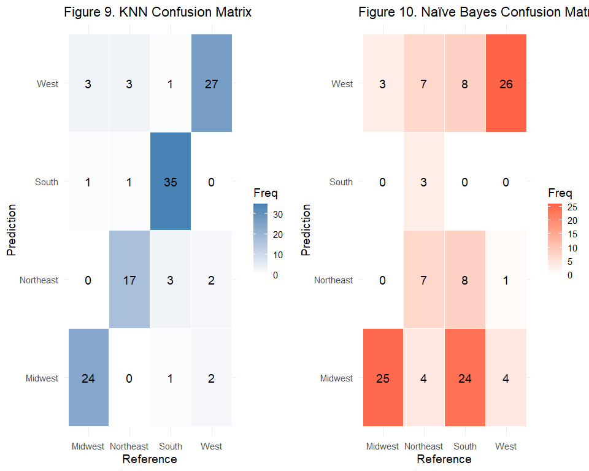

```r
library(ggplot2)
library(caret)
library(reshape2)

# --- KNN Confusion Matrix ---
knn_cm <- confusionMatrix(knn_pred, test_data$Region)
knn_df <- as.data.frame(knn_cm$table)
colnames(knn_df) <- c("Prediction", "Reference", "Freq")

p1 <- ggplot(knn_df, aes(x = Reference, y = Prediction, fill = Freq)) +
  geom_tile(color = "white") +
  geom_text(aes(label = Freq), size = 5) +
  scale_fill_gradient(low = "white", high = "steelblue") +
  labs(title = "Figure 9. KNN Confusion Matrix") +
  theme_minimal(base_size = 14)

# --- Naive Bayes Confusion Matrix ---
nb_cm <- confusionMatrix(nb_pred, test_data$Region)
nb_df <- as.data.frame(nb_cm$table)
colnames(nb_df) <- c("Prediction", "Reference", "Freq")

p2 <- ggplot(nb_df, aes(x = Reference, y = Prediction, fill = Freq)) +
  geom_tile(color = "white") +
  geom_text(aes(label = Freq), size = 5) +
  scale_fill_gradient(low = "white", high = "tomato") +
  labs(title = "Figure 10. Naïve Bayes Confusion Matrix") +
  theme_minimal(base_size = 14)

# Show plots side by side
library(gridExtra)
grid.arrange(p1, p2, ncol = 2)
```

| Model | Accuracy |
| --- | --- |
| KNN | 0.8583 |
| Naïve Bayes | 0.4833 |

```
**Result** KNN gives higher accuracy than Naïve Bayes.
```

## Model Comparison Results

### KNN Model

KNN achieved 85.8% accuracy with a kappa of 0.81.  
The model uses AvgPrice_Adj and density effectively to classify states by region.  
Sensitivity and specificity are both high, usually above 0.85.  
Misclassifications occur between Midwest and West and between Northeast and South.

### Naïve Bayes Model

Naïve Bayes achieved 48.3% accuracy with a kappa of 0.32.  
The independence assumption between AvgPrice_Adj and density is not valid here.  
Housing prices and density are correlated which reduces model performance.  
The model failed to classify any states in the South region correctly.  
Performance for the West region was better with sensitivity around 0.84.

### Reason for Performance Difference

KNN adapts well when relationships between predictors and class are non-linear or overlapping.  
Naïve Bayes assumes independence and Gaussian distributions which do not hold here.

## Conclusion

Real house prices increased from 1975 to 2025.  
Regional trends show different growth rates.  
Population density has a positive link with price change.  
The overall correlation is shown above.  
KNN predicts the region with high accuracy.  
Naïve Bayes is less accurate.  
The findings support the research goal.  
Future work can add more economic factors.

```r
knitr::purl("HousePrice.Rmd", output = "HousePriceRScript.R")
```

[output not shown]